# Running Real-Time Predictions using a SageMaker Hosted Model Endpoint

Using Linear Learner with the MNIST dataset to predict whether a hand writen digit is a 0 or not. Based on the following AWS sample: https://github.com/aws/amazon-sagemaker-examples/blob/main/introduction_to_amazon_algorithms/linear_learner_mnist/linear_learner_mnist.ipynb

## Introduction

The [MNIST](https://en.wikipedia.org/wiki/MNIST_database) dataset consists of images of handwritten digits, from zero to nine. The individual pixel values from each 28 x 28 grayscale image of the digit will be used to predict a yes or no label of whether the digit is a 0 or some other digit (1, 2, 3, ... 9).

Linear Learner will be used to perform a binary classification. The `predicted_label` will take a value of either `0` or `1` where `1` denotes that we predict the image is a 0, while `0` denotes that we are predicting the image is not of a 0.

## Prequisites and Preprocessing

The notebook works with SageMaker Studio Jupyter Lab.

Specify:

- The S3 bucket and prefix to use for training and model data.
- The IAM role arn used to give training and hosting access to your data

```python
import sagemaker

bucket = sagemaker.Session().default_bucket()
prefix = "sagemaker/DEMO-linear-mnist"

# Define IAM role
import boto3
import re
from sagemaker import get_execution_role

role = get_execution_role()
```

```
sagemaker.config INFO - Not applying SDK defaults from location: /etc/xdg/sagemaker/config.yaml
sagemaker.config INFO - Not applying SDK defaults from location: /home/sagemaker-user/.config/sagemaker/config.yaml
```

### Data ingestion

Ingest the dataset from an online URL into memory, for preprocessing prior to training. As it's a small data set, we can do this in memory.

```python
%%time
import pickle, gzip, numpy, urllib.request, json

fobj = (
    boto3.client("s3")
    .get_object(
        Bucket=f"sagemaker-example-files-prod-{boto3.session.Session().region_name}",
        Key="datasets/image/MNIST/mnist.pkl.gz",
    )["Body"]
    .read()
)

with open("mnist.pkl.gz", "wb") as f:
    f.write(fobj)

# Load the dataset
with gzip.open("mnist.pkl.gz", "rb") as f:
    train_set, valid_set, test_set = pickle.load(f, encoding="latin1")
```

```
CPU times: user 1.08 s, sys: 338 ms, total: 1.41 s
Wall time: 2.39 s
```

### Data inspection

Once the dataset is imported we can inspect at one of the digits that is part of the dataset.

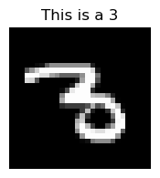

```python
%matplotlib inline
import matplotlib.pyplot as plt

plt.rcParams["figure.figsize"] = (2, 10)


def show_digit(img, caption="", subplot=None):
    if subplot == None:
        _, (subplot) = plt.subplots(1, 1)
    imgr = img.reshape((28, 28))
    subplot.axis("off")
    subplot.imshow(imgr, cmap="gray")
    plt.title(caption)


show_digit(train_set[0][30], "This is a {}".format(train_set[1][30]))
```

### Convert the Data to recordIO-wrapped protobuf format

Amazon SageMaker's version of Linear Learner takes recordIO-wrapped protobuf (or CSV) So we need to convert the data to a suppported format so the algorithm can use it.

The following code converts the np.array to recordIO-wrapped protobuf format.

```python
import io
import numpy as np
import sagemaker.amazon.common as smac

vectors = np.array([t.tolist() for t in train_set[0]]).astype("float32")
labels = np.where(np.array([t.tolist() for t in train_set[1]]) == 0, 1, 0).astype("float32")

buf = io.BytesIO()
smac.write_numpy_to_dense_tensor(buf, vectors, labels)
buf.seek(0)
```

```
0
```

## Upload training data

Now that we've created our recordIO-wrapped protobuf, we'll need to upload it to S3, so that Amazon SageMaker training can use it.

```python
import boto3
import os

key = "recordio-pb-data"
boto3.resource("s3").Bucket(bucket).Object(os.path.join(prefix, "train", key)).upload_fileobj(buf)
s3_train_data = "s3://{}/{}/train/{}".format(bucket, prefix, key)
print("uploaded training data location: {}".format(s3_train_data))
```

```
uploaded training data location: s3://sagemaker-us-east-2-012345678901/sagemaker/DEMO-linear-mnist/train/recordio-pb-data
```

Setup an output S3 location for the model artifact that will be output as the result of training with the algorithm.

```python
output_location = "s3://{}/{}/output".format(bucket, prefix)
print("training artifacts will be uploaded to: {}".format(output_location))
```

```
training artifacts will be uploaded to: s3://sagemaker-us-east-2-012345678901/sagemaker/DEMO-linear-mnist/output
```

```python
from sagemaker.image_uris import retrieve

container = retrieve("linear-learner", boto3.Session().region_name)
```

Start the training job.

- `feature_dim` is 784, which is the number of pixels in each 28 x 28 image.
- `predictor_type` is 'binary_classifier' - we are trying to predict whether the image is or is not a 0.
- `mini_batch_size` is set to 200.

```python
import boto3

sess = sagemaker.Session()

linear = sagemaker.estimator.Estimator(
    container,
    role,
    train_instance_count=1,
    train_instance_type="ml.m5.large",
    output_path=output_location,
    sagemaker_session=sess,
)
linear.set_hyperparameters(feature_dim=784, predictor_type="binary_classifier", mini_batch_size=200)

linear.fit({"train": s3_train_data})
```

```
train_instance_count has been renamed in sagemaker>=2.
See: https://sagemaker.readthedocs.io/en/stable/v2.html for details.
train_instance_type has been renamed in sagemaker>=2.
See: https://sagemaker.readthedocs.io/en/stable/v2.html for details.
INFO:sagemaker:Creating training-job with name: linear-learner-2025-01-03-19-48-05-629
```

[output not shown]

[output cut: 1010 more lines]

[output not shown]

## Configure a Model Endpoint

After training is completed, we can deploy our model using a SageMaker real-time hosted endpoint. This will allow us to make predictions (or inference) from the model dynamically.

```python
from sagemaker.serializers import CSVSerializer
from sagemaker.deserializers import JSONDeserializer

linear_predictor = linear.deploy(
    initial_instance_count=1,
    instance_type="ml.m5.large",
    serializer=CSVSerializer(),
    deserializer=JSONDeserializer(),
)
```

```
INFO:sagemaker:Creating model with name: linear-learner-2025-01-03-20-23-45-715
INFO:sagemaker:Creating endpoint-config with name linear-learner-2025-01-03-20-23-45-715
INFO:sagemaker:Creating endpoint with name linear-learner-2025-01-03-20-23-45-715
```

```
-------!
```

## Validate the model for use

Finally, we can now validate the model for use. We can pass HTTP POST requests to the endpoint to get back predictions. To make this easier, we'll again use the Amazon SageMaker Python SDK and specify how to serialize requests and deserialize responses that are specific to the algorithm.

Now let's try getting a prediction for a single record.

```python
result = linear_predictor.predict(train_set[0][30:31])
print(result)
```

```
{'predictions': [{'score': 3.780493784688588e-08, 'predicted_label': 0}]}
```

If everything works, the endpoint will return a prediction: `predicted_label` which will be either `0` or `1`. `1` denotes that we predict the image is a 0, while `0` denotes that we are predicting the image is not of a 0.

It also gives a `score` which is a single floating point number indicating how strongly the algorithm believes it has predicted correctly.

### Clean up - Delete the Endpoint

The delete_endpoint line in the cell below will remove the hosted endpoint to avoid any unnecessary charges. We should also delete the S3 buckets as well.

```python
sagemaker.Session().delete_endpoint(linear_predictor.endpoint)
```

```
WARNING:sagemaker.deprecations:The endpoint attribute has been renamed in sagemaker>=2.
See: https://sagemaker.readthedocs.io/en/stable/v2.html for details.
INFO:sagemaker:Deleting endpoint with name: linear-learner-2025-01-03-20-23-45-715
```